# Исследование сетевых параметров публичных DNS серверов

## Цель работы

Проанализировать сетевые параметры публичных DNS серверов, сделать мотивированный вывод о предпочтительных серверах

## Используемое ПО

1. Rstudio IDE
2. tracert/traceroute
3. ping
4. whois

## Варианты решения задачи

1. Решить задачу на Windows (с помощью утилиты tracert)
2. Решить задачу на Linux (с помощью утилиты traceroute)

## Ход работы

1. По исследуемым серверам собрать следующие данные:
- маршрут
- местоположение каждого узла маршрута к DNS-серверу
- организацию, владеющую каждым узлом маршрута к DNS-серверу
- среднюю RTT (round trip time) к DNS-серверу
2. Выделить те узлы маршрута, которые вносят наибольшую временную задержку при передаче
3. Сравнить сетевые параметры DNS серверов

## Исследуемые провайдеры DNS

1. Google Public DNS
2. Cloudflare DNS
3. OpenDNS
4. DNS вашего провайдера

## Содержание лабораторной работы:

### 1.Google Public DNS - 8.8.8.8

Google Public DNS — интернет-сервис корпорации Google.

Для начала определим доступность адреса

```
system("ping 8.8.8.8",timeout = 5 , intern = TRUE)
```

Теперь определим маршрут

```
system("tracert 8.8.8.8", intern = TRUE)
```

### Информационная таблица:

| № | Первый ping | Второй ping | Третий ping | Узел | Месторасположение | Организация | Средняя RTT |
| --- | --- | --- | --- | --- | --- | --- | --- |
| 1 | * | * | * | Request timed out. |  |  |  |
| 2 | 3 ms | 3 ms | 3 ms | 10.133.0.1 | USA, Лос-Анджелес | Internet Assigned Numbers Authority | 3 |
| 3 | 4 ms | 4 ms | 4 ms | mpts-ss-51.msk.mts-internet.net [212.188.1.6] | Москва | MTS / former ZAO MTU-Intel’s p2p Network | 4 |
| 4 | 4 ms | 4 ms | 4 ms | mag9-cr01-be12.51.msk.mts-internet.net [212.188.1.5] | Москва | MTS / former ZAO MTU-Intel’s p2p Network | 4 |
| 5 | 4 ms | 4 ms | 4 ms | 72.14.223.72 | USA, Mountain View | Google LLC | 4 |
| 6 | 6 ms | 5 ms | 5 ms | 108.170.250.34 | USA, Mountain View | Google LLC | 5.3 |
| 7 | 18 ms | 18 ms | 18 ms | 216.239.50.46 | USA | Google LLC | 18 |
| 8 | 19 ms | 18 ms | 18 ms | 216.239.54.50 | USA | Google LLC | 18.3 |
| 9 | * | * | * | Request timed out. |  |  |  |
| 10 | * | * | * | Request timed out. |  |  |  |
| 11 | * | * | * | Request timed out. |  |  |  |
| 12 | * | * | * | Request timed out. |  |  |  |
| 13 | * | * | * | Request timed out. |  |  |  |
| 14 | * | * | * | Request timed out. |  |  |  |
| 15 | * | * | * | Request timed out. |  |  |  |
| 16 | * | * | * | Request timed out. |  |  |  |
| 17 | * | * | * | Request timed out. |  |  |  |
| 18 | * | * | * | Request timed out. |  |  |  |
| 19 | * | * | * | Request timed out. |  |  |  |
| 20 | 19 ms | 18 ms | 24 ms | dns.google [8.8.8.8] | USA, Нью-Йорк | Google LLC | 20.3 |

### 2.Cloudflare DNS - 1.1.1.1

Cloudflare -предоставляют защиту для он-лайн сервисов от DDoS-атак путём фильтрации паразитного трафика на своих прокси-серверах.

Для начала определим доступность адреса

```
system("ping 1.1.1.1",timeout = 5 , intern = TRUE)
```

Теперь определим маршрут

```
system("tracert 1.1.1.1", intern = TRUE)
```

### Информационная таблица:

| № | Первый ping | Второй ping | Третий ping | Узел | Месторасположение | Организация | Средняя RTT |
| --- | --- | --- | --- | --- | --- | --- | --- |
| 1 | * | * | * | Request timed out. |  |  |  |
| 2 | 3 ms | 3 ms | 2 ms | 10.133.0.1 | USA, Лос-Анджелес | Internet Assigned Numbers Authority | 2.6 |
| 3 | 4 ms | 4 ms | 4 ms | mpts-ss-51.msk.mts-internet.net [212.188.1.6] | Москва | MTS / former ZAO MTU-Intel’s p2p Network | 4 |
| 4 | 4 ms | 3 ms | 4 ms | mag9-cr01-be12.51.msk.mts-internet.net [212.188.1.5] | Москва | MTS / former ZAO MTU-Intel’s p2p Network | 3.6 |
| 5 | 5 ms | 5 ms | 5 ms | m9-cr04-be8.77.msk.mts-internet.net [212.188.54.213] | Москва | MTS / former ZAO MTU-Intel’s p2p Network | 5 |
| 6 | 4 ms | 4 ms | 4 ms | m9-cr05-ae3.77.msk.mts-internet.net [195.34.53.185] | Москва | MTS / former ZAO MTU-Intel’s p2p Network | 4 |
| 7 | 31 ms | 23 ms | 25 ms | 172.68.8.254 | Ukraine, Киев | Cloudflare, Inc. | 26.3 |
| 8 | 31 ms | 29 ms | 29 ms | one.one.one.one [1.1.1.1] | Australia, Research | APNIC and Cloudflare DNS Resolver project | 29.6 |

### 3.OpenDNS - 208.67.220.220

OpenDNS — интернет-служба, предоставляющая общедоступные DNS-серверы.

Для начала определим доступность адреса

```
system("ping 208.67.220.220",timeout = 5 , intern = TRUE)
```

Теперь определим маршрут

```
system("tracert 208.67.220.220", intern = TRUE)
```

### Информационная таблица:

| № | Первый ping | Второй ping | Третий ping | Узел | Месторасположение | Организация | Средняя RTT |
| --- | --- | --- | --- | --- | --- | --- | --- |
| 1 | * | * | * | Request timed out. |  |  |  |
| 2 | 3 ms | 3 ms | 3 ms | 10.133.0.1 | USA, Лос-Анджелес | Internet Assigned Numbers Authority | 3 |
| 3 | 4 ms | 4 ms | 4 ms | mpts-ss-51.msk.mts-internet.net [212.188.1.6] | Москва | MTS, former ZAO MTU-Intel’s p2p Network | 4 |
| 4 | 4 ms | 4 ms | 4 ms | mag9-cr01-be12.51.msk.mts-internet.net [212.188.1.5] | Москва | MTS, former ZAO MTU-Intel’s p2p Network | 4 |
| 5 | 4 ms | 4 ms | 4 ms | a197-cr04-be10.77.msk.mts-internet.net [195.34.50.73] | Москва | MTS PJSC | 4 |
| 6 | 109 ms | 109 ms | 109 ms | che-cr02-ae1.63.sam.mts-internet.net [212.188.29.26] | Москва | MTS, former ZAO MTU-Intel’s p2p Network | 109 |
| 7 | 35 ms | 35 ms | 34 ms | psshag-cr01-ae10.63.chel.mts-internet.net [212.188.42.130] | Москва | MTS, former ZAO MTU-Intel’s p2p network | 34.6 |
| 8 | 54 ms | 70 ms | 54 ms | bhm-cr01-ae12.74.nsk.mts-internet.net [195.34.50.154] | Москва | MTS PJSC | 59.3 |
| 9 | 109 ms | 109 ms | 109 ms | sem275-cr01-ae5.24.krsk.mts-internet.net [212.188.29.10] | Москва | MTS, former ZAO MTU-Intel’s p2p Network | 109 |
| 10 | 109 ms | 109 ms | 109 ms | akd-cr01-ae8.38.irk.mts-internet.net [212.188.29.138] | Москва | MTS, former ZAO MTU-Intel’s p2p Network | 109 |
| 11 | 109 ms | 110 ms | 109 ms | psskv-cr01-ae6.28.skv.mts-internet.net [212.188.28.213] | Москва | MTS, former ZAO MTU-Intel’s p2p Network | 109.3 |
| 12 | 108 ms | 108 ms | 109 ms | teat-cr01-ae0.28.blag.mts-internet.net [212.188.2.106] | Москва | MTS OJSC, former ZAO MTU-Intel’s p2p Network | 108.3 |
| 13 | * | * | * | Request timed out. |  |  |  |
| 14 | 240 ms | 240 ms | 241 ms | resolver1.opendns.com [208.67.220.220] | USA, San Francisco | Cisco OpenDNS, LLC | 240.3 |

### 4.MGTS - 62.112.96.14

Для начала определим доступность адреса

```
system("ping 62.112.96.14",timeout = 5 , intern = TRUE)
```

Теперь определим маршрут

```
system("tracert 62.112.96.14", intern = TRUE)
```

### Информационная таблица:

| № | Первый ping | Второй ping | Третий ping | Узел | Месторасположение | Организация | Средняя RTT |
| --- | --- | --- | --- | --- | --- | --- | --- |
| 1 | * | * | * | Request timed out. |  |  |  |
| 2 | 2 ms | 2 ms | 3 ms | 10.133.0.1 | USA, Лос-Анджелес | Internet Assigned Numbers Authority | 2.3 |
| 3 | 4 ms | 4 ms | 4 ms | 10.215.240.105 | USA, Лос-Анджелес | Internet Assigned Numbers Authority | 4 |
| 4 | * | * | * | Request timed out. |  |  |  |
| 5 | 5 ms | 5 ms | 15 ms | 10.215.240.109 | USA, Лос-Анджелес | Internet Assigned Numbers Authority | 8.3 |
| 6 | 6 ms | 4 ms | 4 ms | 62.112.96.13 | Москва | MGTS adsl-rfc Client | 4.6 |
| 7 | 4 ms | 4 ms | 4 ms | 62.112.96.14 | Москва | MGTS adsl-rfc Client | 4 |

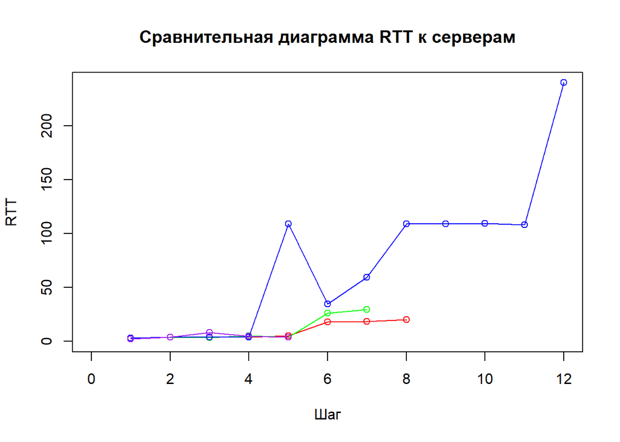

1. Цветовое обозначение:
- Красный - Google Public DNS
- Зеленый - Cloudflare DNS
- Синий - OpenDNS
- Фиолетовый - MGTS

## Оценка результата

На графике видно, что больше всего времени потребовалось при обращении к OpenDNS, меньше всего - к MGTS.

## Вывод

DNS важна для работы Интернета, так как для соединения с узлом необходима информация о его IP-адресе, а для людей проще запоминать буквенные (обычно осмысленные) адреса, чем последовательность цифр IP-адреса. В данной лабораторной работе мы рассмотрели параметры Google Public DNS, Cloudflare DNS, OpenDNS, MGTS.